# Problem Set 1

Yifan Jing (UNI - yj2606), Keertan Krishnan(UNI - kk3446)

First, we load the ‘tidyverse’ package by running this code:

```r
library(tidyverse)
```

### 1. Education and Income

1. Draw multiple horizontal boxplots of `Income2005`, by `Educ` (education level). Order the boxplots from lowest educational level at the bottom to highest educational level at the top. (Hint: reorder factor levels) What do you observe?

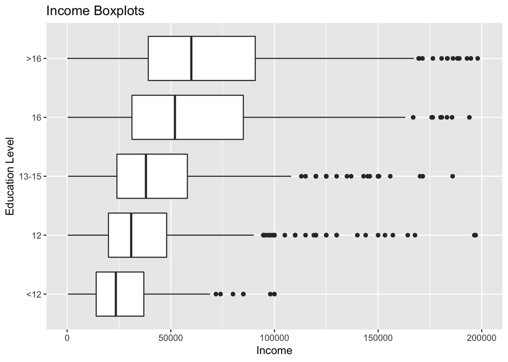

- The average level of income increases with education level increasing.
- There are lots of outliers which are much higher than average income in every education level.
2. Draw histograms, faceted by `Educ`, for the same data. Describe one insight that was not visible in the boxplots.

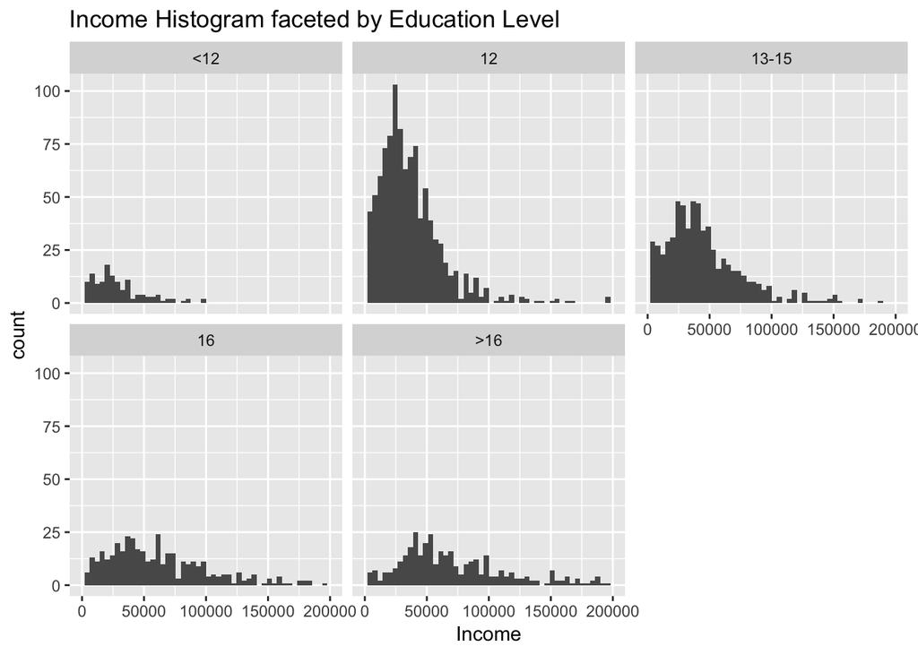

- The income with education level = ‘12’ has an obvious peak at about 25000 while others don’t.
- This goes to show that boxplots are not good at finding if the data is unimodal or not.
3. Plot overlapping density curves of the same data, one curve per education level, on a single set of axes. Each curve should be a different color. What additional information do you learn?

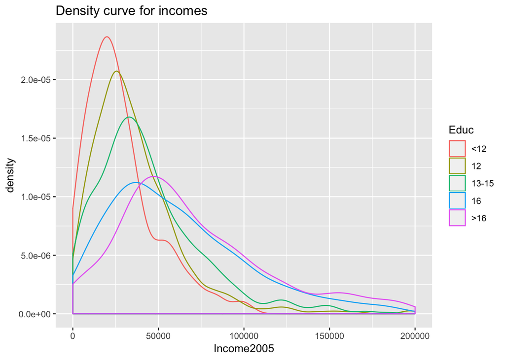

- The income distribution of education level ‘<12’, ‘12’, ‘13-15’ are similar; the distribution of ‘16’ and ‘>16’ are similar. And they both look like normal distribution which is skewed to the right.
- In addition, as people’s duration of education increased, the median of the incomes increased. This goes to show that if someone did study for longer, they had a good chance of drawing a higher income. However, the spread (standard deviation) of the density functions increased as the education increased.

### 2. Boundaries

1. Find or create a small dataset (< 100 observations) for which right open and right closed histograms for the same parameters are not identical. Display the full dataset (that is, show the numbers) and the plots of the two forms.

```
##  [1] 50 50 51 51 51 52 52 53 54 55 55 55 55 55 55 55 56 56 57 57 58 58 60 60 60
## [26] 60 60 60 60 61 62 62 63 64 64 65 65 68 70 70 70 70 70 70 70 70 70 71 72 75
```

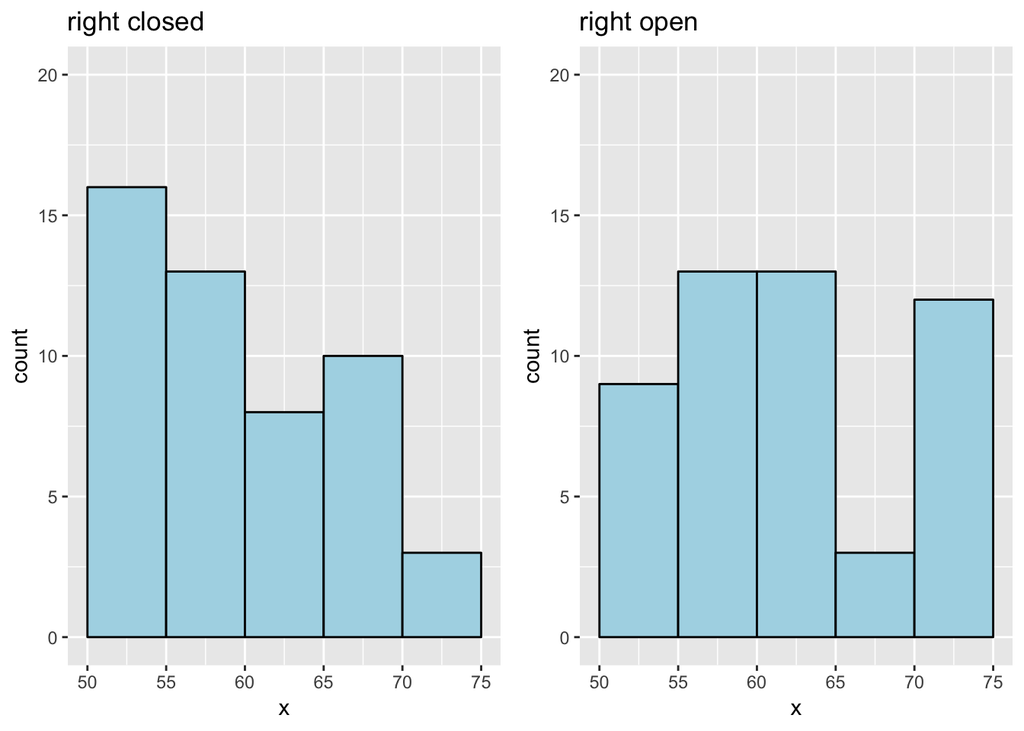

2. Adjust parameters–the same for both–so that the right open and right closed versions become identical. Explain your strategy.

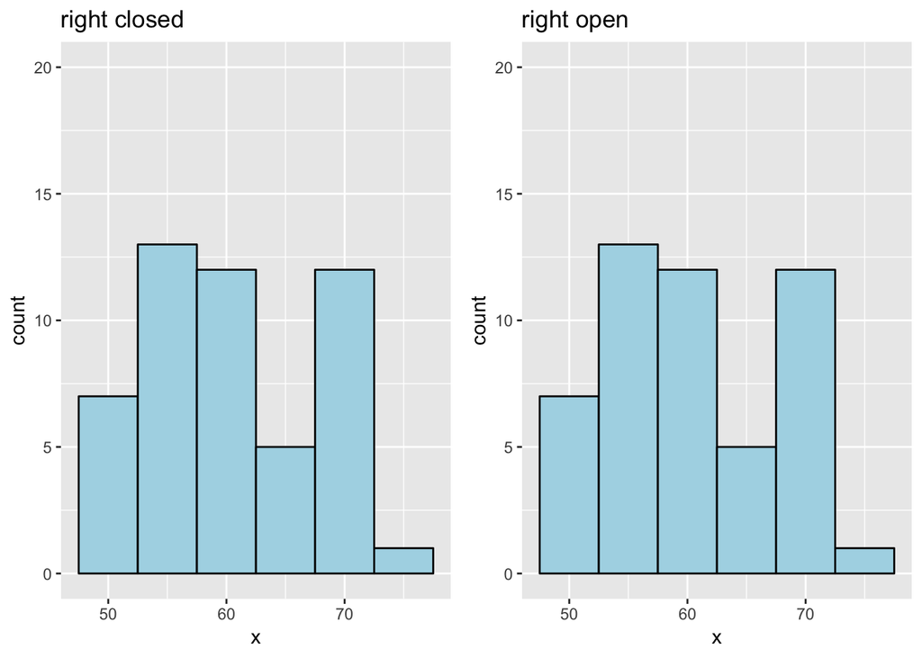

- By changing the parameter ‘center’ from 52.5 to 50, each data value is placed into bins in such a way that there are no values at the boundaries of bins themselves (as the boundaries are 47.5-52.5, 52.5-57.5 and so on). Thus, in such a case, it does not matter whether a right closed strategy is used, or a right open strategy.

### 3. Beavers

1. Use QQ (quantile-quantile) plots with theoretical normal lines to compare `temp` for the built-in `beaver1` and `beaver2` datasets. Which appears to be more normally distributed?

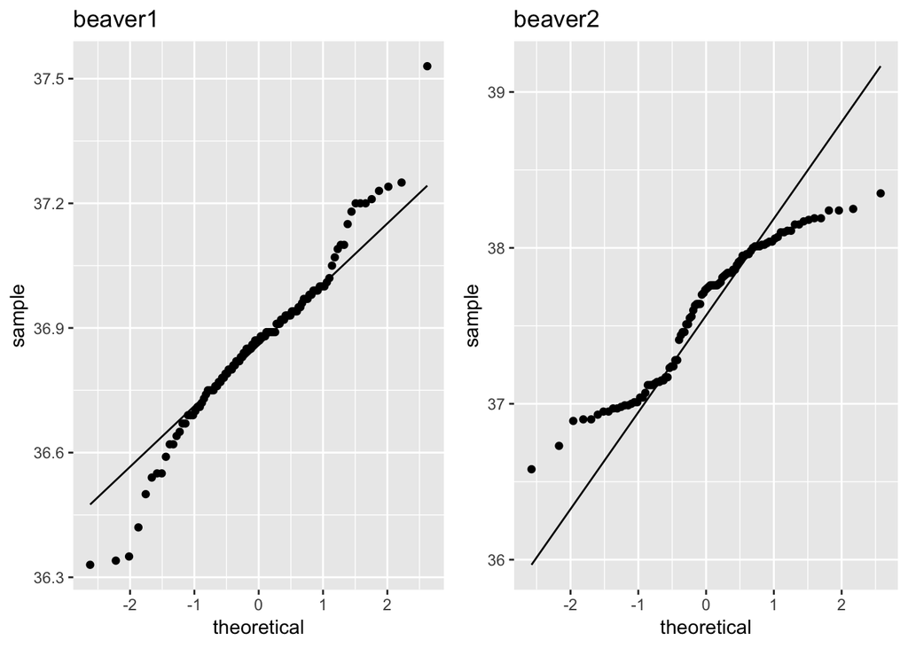

- Beaver1 appears to be more normally distributed, especially through the middle quantiles. Quite significant deviations are seen in this portion of the beaver2 dataset, whereas it seems that beaver 1 conforms to the normal deviation better.
2. Draw density histograms with density curves and theoretical normal curves overlaid. Does the data appear to be normally distributed?

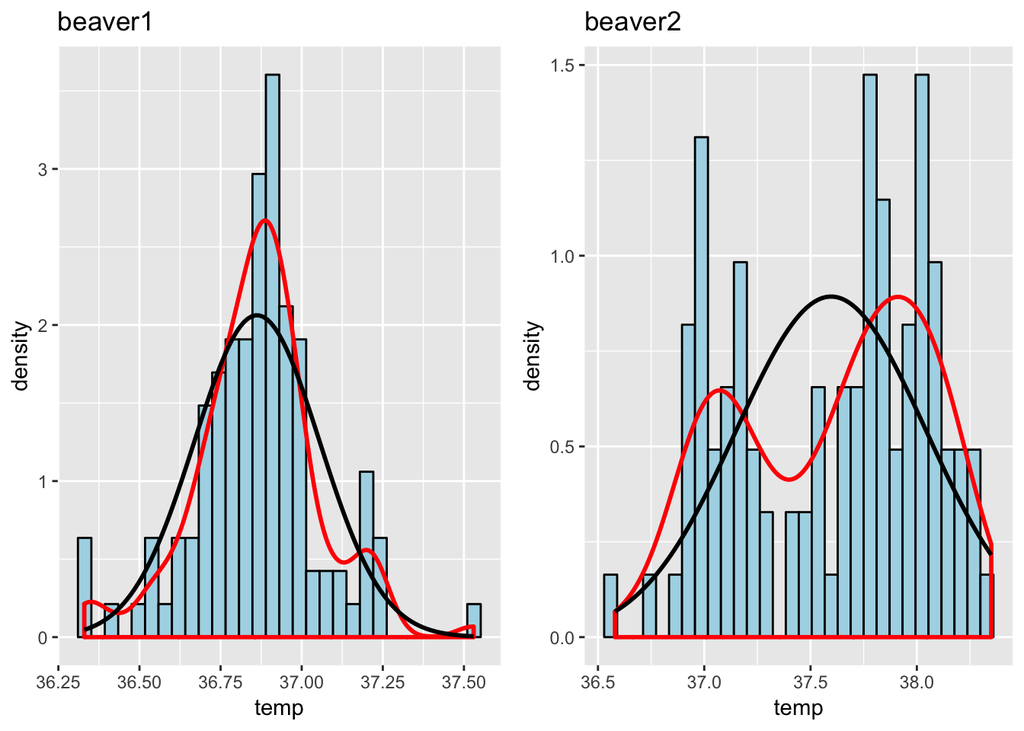

- Beaver1 appears to be normally distributed but beaver2 doesn’t.
3. Perform the Shapiro-Wilk test for normality using the `shapiro.test()` function and interpret the results.

```r
shapiro.test(beaver1$temp)
```

```
##
##  Shapiro-Wilk normality test
##
## data:  beaver1$temp
## W = 0.97031, p-value = 0.01226
```

```r
shapiro.test(beaver2$temp)
```

```
##
##  Shapiro-Wilk normality test
##
## data:  beaver2$temp
## W = 0.93336, p-value = 7.764e-05
```

- The p-value of beaver2 is much smaller than p-value of beaver1. So it means we are more likely to reject the hypothesis that beaver2 is normally distributed than beaver1. Hence, beaver1 is more likely to be normally distributed.
4. Did all of the methods for testing for normality (a, b, and c) produce the same results? Briefly explain.
- Yes, they produce the same results. In test a, we can find that QQplot of beaver1 is more like a theoretical normal line than beaver2; in test b, the density curve of beaver1 is more close to theoretical normal curve than beaver2; in test c, the p-value of beaver2 is much smaller than p-value of beaver1, which means we are more likely to reject the hypothesis that beaver2 is normally distributed than beaver1.

### 4. Doctors

Draw two histograms of the age of death attributed to coronary artery disease among doctors in the breslow dataset (boot package), one for smokers and one for non-smokers.

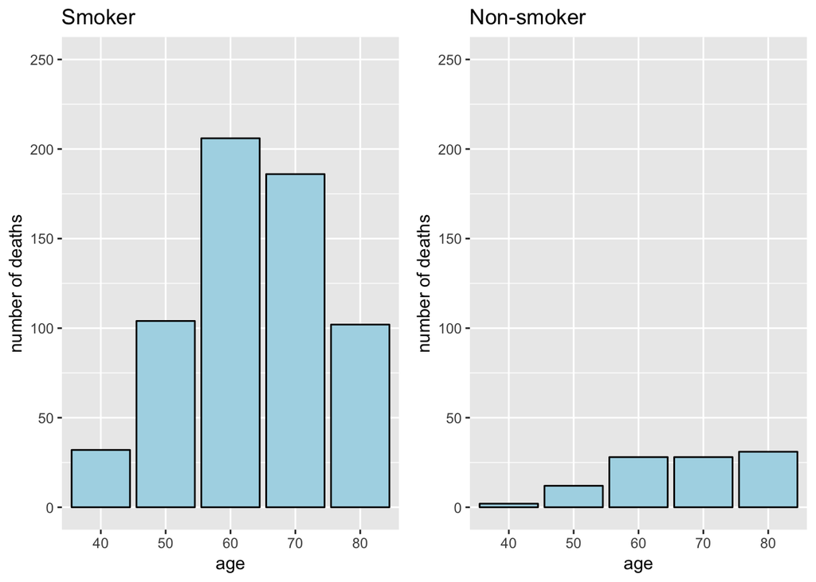

- We draw two histograms of the number of deaths, by age.
- For every age group, the number of deaths for those who are smokers is higher than that of non-smokers. However, as the number of total participants being studied along with the proportion of total participants who are smokers vs non-smokers is unclear, we do not know if the death rate (number of deaths/person-years) is higher for the smokers group.
- So we think it would be more helpful if we draw histograms of death rate which is ‘y/n’ in the dataset and we draw it below.

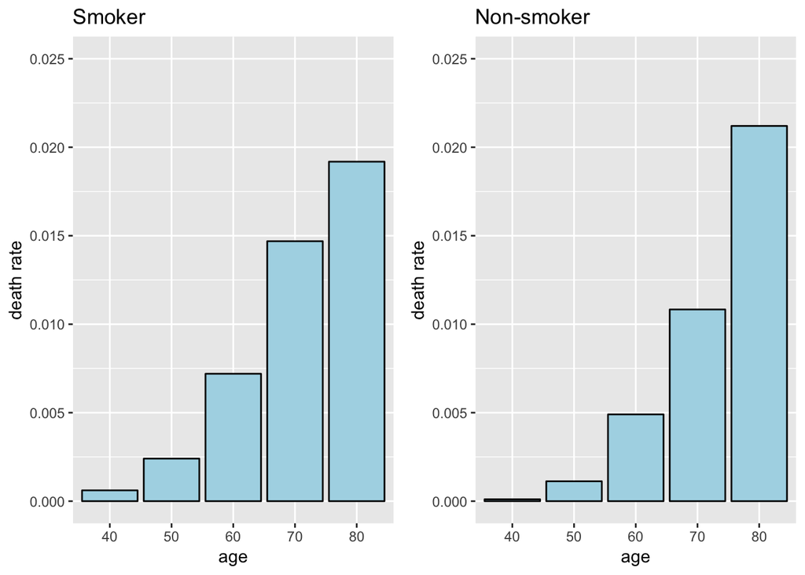

- From these graphs of the death rate itself, it is clear to see that for the age brackets of 35-75, the death rate for smokers is higher than the corresponding non-smoker death rate. However, interestingly, for the age group of 75-85, we find the death rate is higher for the non-smoker group in comparison to the smoker group. This might be due to lack of data.

### 5. Nutrition

1. Create a new categorical variable that represents ages in 10-year groups: 0-10, 11-20, 21-30, etc. Choose one of the continuous variables in the dataset and create a ridgeline plot (**ggridges** package) showing the distribution of the chosen variable by age.

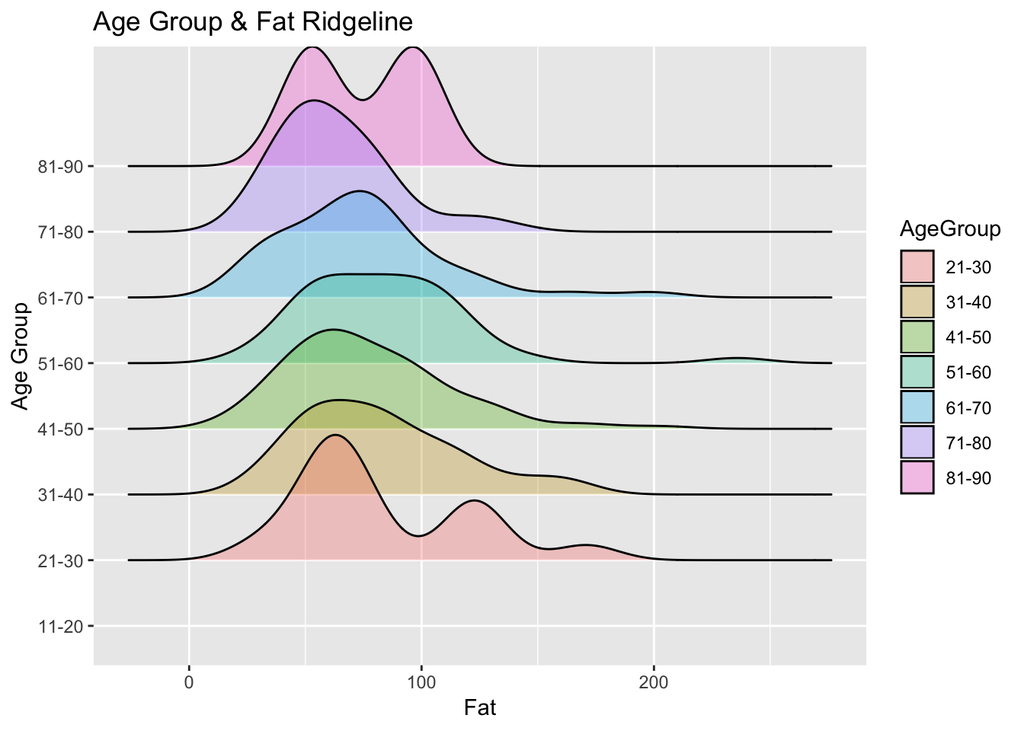

2. Display the same data as in part a) using boxplots.

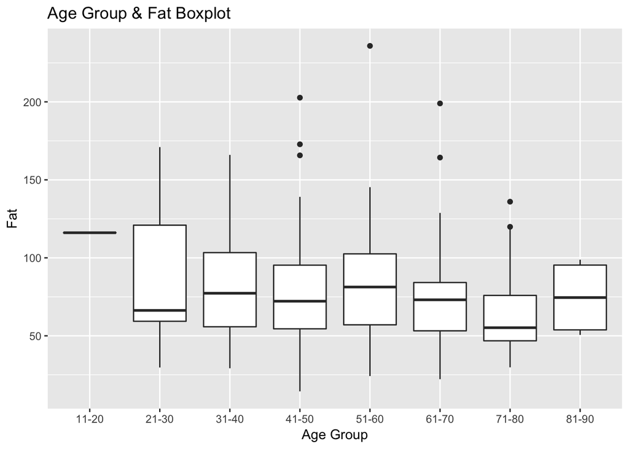

3. Compare a) and b). Which do you think is more effective for this data and why?
- We think a) is more effective. Because for this data, the average level of continuous variable that we choose has no obvious linear relationship with Age_group, which means we can’t get enough information from boxplot. But from ridgeline plot, we can easily find the distribution of fat by Age_group which is more direct for this data.
- It is very clear that boxplots are quite bad at figuring out whether the data is unimodal or multimodal. Ridgeline plots are much better at these tasks.
- However, a merit of the boxplot in contrast to the ridgeline plot is that boxplots are excellent at showing the outliers whereas ridgeplots are not good at this.